# Projet 3 : Classification bayésienne et analyse factorielle discriminante

Antoine LI, Lucas TONLOP

2025-2026

## Introduction

Ce projet a pour but de développer une chaîne de traitement NLP (Natural Language Processing) pour classifier des thèses de doctorat françaises. L’objectif principal est de prédire le domaine d’étude (la variable cible) à partir du résumé de la thèse (variable textuelle).

## 1. Chargement et exploration des données

Le jeu de données complet contient plus de 400 000 thèses. C’est un volume important difficile à traiter brut. Les variables principales sont `Description` (le résumé) et `Domain` (la classe à prédire). Pour garantir la fiabilité du modèle, nous allons nous concentrer sur les domaines les plus représentés.

```r
# Chargement des librairies nécessaires
library(readr)
library(dplyr)
library(ggplot2)
```

```r
# 1.1 Chargement et Filtrage des données
# Source des données : Recherche de similarité sémantique de thèse de doctorat française (Kaggle)

data_raw <- read_csv("french_thesis_20231021_metadata.csv", show_col_types = FALSE)

# Nettoyage des lignes vides
data_clean <- data_raw %>%
  select(Description, Domain) %>%
  filter(!is.na(Description) & !is.na(Domain))

# Sélection des Top Domaines :
# Nous ne gardons que les 20 domaines les plus fréquents.
# Cela permet d'avoir assez d'exemples par classe pour que le modèle apprenne correctement.
top_20_domains <- names(sort(table(data_clean$Domain), decreasing = TRUE)[1:20])

data_filtered <- data_clean %>%
  filter(Domain %in% top_20_domains)

# Échantillonnage : On travaille sur 10 000 thèses aléatoires parmi ces domaines
set.seed(123)
data <- data_filtered %>% sample_n(min(nrow(data_filtered), 10000))

# On nettoie les "niveaux" (catégories) vides après le filtrage
data$Domain <- droplevels(as.factor(data$Domain))
```

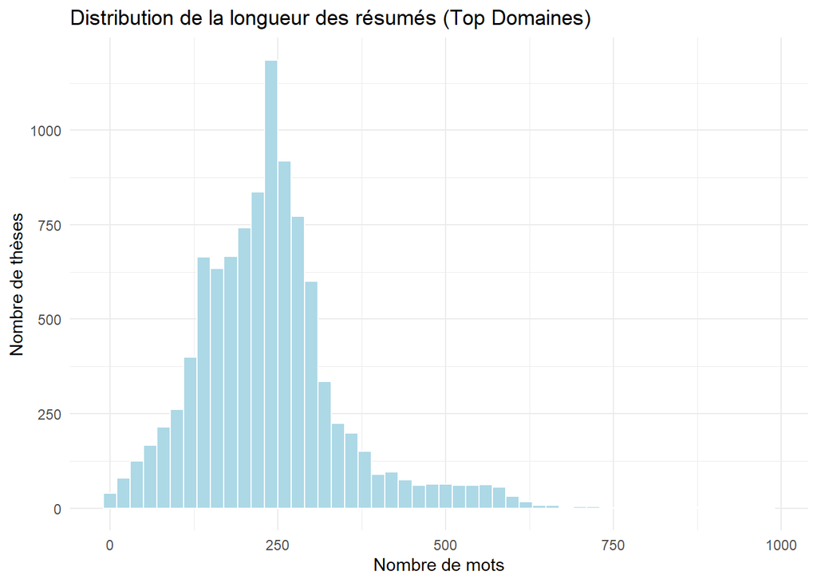

```
## [1] "Nombre de lignes : 10000"
## [1] "Nombre de domaines retenus : 20"
##
##                                                  Informatique
##                                                          1185
##                                                      Physique
##                                                          1105
##                                                        Chimie
##                                                           716
##                                          Sciences économiques
##                                                           659
## Sciences biologiques et fondamentales appliquées. Psychologie
##                                                           623
##                                           Sciences appliquées
##                                                           617
##                                                      Histoire
##                                                           530
##                                           Sciences de gestion
##                                                           460
##                                                    Sociologie
##                                                           455
##                                                   Psychologie
##                                                           424
##                                                  Droit public
##                                                           415
##                                                   Droit privé
##                                                           413
##                                                 Mathématiques
##                                                           411
##                                                   Philosophie
##                                                           344
##                                                    Géographie
##                                                           332
##                                                         Droit
##                                                           327
##                                       Sciences de l'éducation
##                                                           269
##                                                 Neurosciences
##                                                           246
##                                          Terre, océan, espace
##                                                           237
##                                                     Mécanique
##                                                           232
```

```r
# 1.2 Analyse descriptive
# Vérification des dimensions finales
print(paste("Nombre de lignes :", nrow(data)))
print(paste("Nombre de domaines retenus :", length(unique(data$Domain))))

# Affichage de la répartition des domaines
print(sort(table(data$Domain), decreasing = TRUE))

# Visualisation de la longueur des résumés
data$longueur_mots <- sapply(strsplit(as.character(data$Description), " "), length)

ggplot(data[data$longueur_mots < 1000, ], aes(x = longueur_mots)) +
  geom_histogram(binwidth = 20, fill = "lightblue", color = "white") +
  theme_minimal() +
  labs(title = "Distribution de la longueur des résumés (Top Domaines)",
       x = "Nombre de mots", y = "Nombre de thèses")
```

## 2. Pré-traitement des données

Le pré-traitement transforme le texte brut en données numériques. Nous procédons en deux étapes majeures : - Nettoyage : Minuscules, suppression de la ponctuation, des chiffres et des mots vides (stopwords). - Vectorisation : Transformation en matrice TF-IDF (Term Frequency-Inverse Document Frequency).

```r
# Chargement des librairies spécifiques au Text Mining (NLP)
library(tm)
library(SnowballC)
```

```r
# 2.1. Nettoyage du texte
# Normalisation : Passage en minuscules pour uniformiser le texte
data$Description_clean <- tolower(data$Description)

# Suppression des caractères non pertinents (bruit)
data$Description_clean <- gsub("[0-9]+", "", data$Description_clean)      # Supprime les chiffres
data$Description_clean <- gsub("[[:punct:]]", " ", data$Description_clean) # Supprime la ponctuation
data$Description_clean <- gsub("\\s+", " ", data$Description_clean)        # Supprime les espaces superflus

# Suppression des Stopwords (mots vides sans sens sémantique)
# Cette étape permet de filtrer les mots très fréquents sans valeur sémantique (le, la, du...)
mots_vides <- stopwords("french")

removeWords_custom <- function(text, words) {
  tokens <- unlist(strsplit(text, " "))
  tokens_filtered <- tokens[!(tokens %in% words)]
  paste(tokens_filtered, collapse = " ")
}

# Application du filtrage sur l'ensemble du corpus
# (Cette opération nettoie le texte pour ne garder que les termes porteurs de sens)
data$Description_clean <- sapply(data$Description_clean, function(x) removeWords_custom(x, mots_vides))

# Stemming (Racinisation) : On garde la racine des mots pour réduire le vocabulaire
# Cela permet de regrouper les variantes d'un même mot et de réduire la dimensionnalité.
tokens_list <- strsplit(data$Description_clean, "\\s+")

data$Description_stemmed <- sapply(tokens_list, function(x) {
  paste(wordStem(x, language = "french"), collapse = " ")
})

# Vérification du résultat sur les premières lignes
sapply(head(data$Description_stemmed, 3), substr, start = 1, stop = 150)
```

[output not shown]

```r
# 2.2. Vectorisation (TF-IDF)
# Création du Corpus et de la Matrice Document-Termes
corpus_final <- Corpus(VectorSource(data$Description_stemmed))

dtm_tfidf <- DocumentTermMatrix(corpus_final,
                                control = list(weighting = weightTfIdf))

# Réduction de dimension (Sparsity)
# On supprime les mots trop rares (n'apparaissant pas dans au moins 1% des thèses) pour éviter de saturer la mémoire.
dtm_clean <- removeSparseTerms(dtm_tfidf, 0.99)

# Conversion finale en DataFrame pour le modèle
tfidf_df <- as.data.frame(as.matrix(dtm_clean))

# Préparation finale du jeu de données
# Nettoyage des noms de colonnes pour compatibilité R
colnames(tfidf_df) <- make.names(colnames(tfidf_df))

# Ajout de la variable cible (Domaine d'étude)
tfidf_df$Domain_Cible <- as.factor(data$Domain)

# Bilan de l'extraction de caractéristiques
print(paste("Nombre de caractéristiques (mots retenus) :", ncol(tfidf_df) - 1))
dim(tfidf_df)

# On crée une copie temporaire sans les noms de lignes pour l'affichage
preview_tfidf <- tfidf_df[1:5, 1:10]
rownames(preview_tfidf) <- paste("Doc", 1:5)
print(preview_tfidf)
```

```
## [1] "Nombre de caractéristiques (mots retenus) : 1710"
## [1] 10000  1711
##             afin        alor     altern     analys       anti     appliqu
## Doc 1 0.02263155 0.025260330 0.04402552 0.01408287 0.05520578 0.020686401
## Doc 2 0.00000000 0.008817285 0.00000000 0.01474716 0.00000000 0.007220725
## Doc 3 0.00000000 0.000000000 0.00000000 0.06106244 0.00000000 0.000000000
## Doc 4 0.00000000 0.000000000 0.00000000 0.00000000 0.00000000 0.000000000
## Doc 5 0.00000000 0.000000000 0.00000000 0.00000000 0.00000000 0.000000000
##         argument   asymptot      champ   classiqu
## Doc 1 0.05727005 0.05815155 0.03196335 0.03482565
## Doc 2 0.00000000 0.00000000 0.00000000 0.00000000
## Doc 3 0.00000000 0.00000000 0.02771822 0.00000000
## Doc 4 0.00000000 0.00000000 0.00000000 0.00000000
## Doc 5 0.00000000 0.00000000 0.00000000 0.06703435
```

## 3. Entraînement du modèle bayésien

Dans cette étape, nous construisons le modèle prédictif. Nous adoptons une approche d’apprentissage supervisé. Pour garantir la validité de nos résultats et éviter le sur-apprentissage (overfitting), nous divisons notre jeu de données en deux sous-ensembles : - Le jeu d’entraînement (Training set, 80%) : Il permet au modèle d’apprendre les probabilités d’association entre les mots (features) et les domaines. - Le jeu de test (Test set, 20%) : Il servira ultérieurement à évaluer la capacité de généralisation du modèle sur des données inédites. Nous préparons également les données en dissociant explicitement les variables explicatives (la matrice des mots) de la variable cible (le domaine), afin d’assurer la compatibilité avec l’algorithme.

```r
# Chargement du package pour diviser les données
if(!require(caret)) install.packages("caret")
library(caret)

# On fixe une "graine" pour que le mélange soit toujours le même à chaque lancement
set.seed(123)

# 1. Partitionnement des données (Stratégie 80/20)
# La fonction createDataPartition assure que la répartition des classes est respectée dans les deux jeux
index_train <- createDataPartition(tfidf_df$Domain_Cible, p = 0.8, list = FALSE)

train_set <- tfidf_df[index_train, ]
test_set  <- tfidf_df[-index_train, ]

# 2. Préparation des matrices X (Features) et Y (Cible)
# Cette séparation est nécessaire pour optimiser le traitement par la librairie 'naivebayes'
col_domaine <- ncol(train_set)
x_train <- as.matrix(train_set[, -col_domaine])
y_train <- train_set[, col_domaine]

print(paste("Entraînement sur", nrow(x_train), "thèses et", ncol(x_train), "mots."))
```

```
## [1] "Entraînement sur 8007 thèses et 1710 mots."
```

```r
# 3. Entraînement du modèle
if(!require(naivebayes)) install.packages("naivebayes")
library(naivebayes)

# Nous utilisons un lissage de Laplace (laplace = 1)
# Cela permet de gérer les mots qui n'apparaîtraient pas dans le jeu d'entraînement
# en évitant d'assigner une probabilité nulle.
modele_nb <- naive_bayes(x = x_train, y = y_train, laplace = 1)
```

## 4. Évaluation et performance du modèle

L’objectif est maintenant de mesurer la fiabilité du modèle. Nous allons le confronter au jeu de test, c’est-à-dire aux thèses qu’il n’a jamais rencontrées lors de la phase d’apprentissage. Nous analyserons deux indicateurs clés : - L’Exactitude (Accuracy) : La proportion globale de prédictions correctes. - La Matrice de Confusion : Elle permet d’identifier précisément quelles classes sont bien prédites et quelles classes sont confondues entre elles.

```r
# 1. Préparation du test
# On sépare les features (x) de la réponse réelle (y)
col_domaine <- ncol(test_set)
x_test <- as.matrix(test_set[, -col_domaine])
y_test_reels <- test_set[, col_domaine]

# 2. Génération des prédictions
# Le modèle estime le domaine le plus probable pour chaque résumé du test
predictions_nb <- predict(modele_nb, newdata = x_test)

# Aperçu des premières classifications
head(predictions_nb)
```

```
## [1] Droit public            Mécanique               Sciences de l'éducation
## [4] Mathématiques           Neurosciences           Chimie
## 20 Levels: Chimie Droit Droit privé Droit public Géographie ... Terre, océan, espace
```

```r
# 3. Analyse des résultats
# Construction de la Matrice de Confusion
matrice_confusion <- table(Prédiction = predictions_nb, Réalité = y_test_reels)

# Calcul de l'Accuracy (Somme de la diagonale / Total)
accuracy <- sum(diag(matrice_confusion)) / sum(matrice_confusion)

print(paste("Précision globale (Accuracy) :", round(accuracy * 100, 2), "%"))

# 4. Visualisation de la matrice de confusion
# Cette matrice croise les prédictions (lignes) avec la réalité (colonnes)
stats_classes <- confusionMatrix(predictions_nb, y_test_reels)$byClass[, "Balanced Accuracy"]
print(round(head(stats_classes, 5), 3))
```

```
## [1] "Précision globale (Accuracy) : 45.91 %"
##       Class: Chimie        Class: Droit  Class: Droit privé Class: Droit public
##               0.771               0.665               0.653               0.661
##   Class: Géographie
##               0.680
```

## 5. Analyse Factorielle Discriminante (AFD)

Conformément à l’intitulé du projet, nous comparons maintenant notre modèle Bayésien avec une Analyse Factorielle Discriminante (LDA). Comme l’AFD gère mal le grand nombre de variables (mots) généré par le TF-IDF, nous procédons d’abord à une réduction de dimension via une Analyse en Composantes Principales (ACP).

```r
# 1. Réduction de dimension par ACP (Analyse en Composantes Principales)
# Cette étape permet de "résumer" l'information des milliers de mots en 50 axes principaux.

print("Calcul de l'ACP en cours (réduction de dimension)...")
# On effectue l'ACP sur les données d'entraînement (uniquement sur les mots, pas le domaine)
# scale. = FALSE car le TF-IDF est déjà une forme de pondération
pca_model <- prcomp(x_train, scale. = FALSE)

# On décide de garder les 50 premières composantes (axes) qui contiennent le plus d'information
n_axes <- 50

# On projette nos données d'entraînement sur ces 50 axes
train_pca <- data.frame(pca_model$x[, 1:n_axes])

# On rajoute la cible (le domaine) pour pouvoir entraîner le modèle
train_pca$Domain_Cible <- y_train

# On projette aussi les données de TEST sur les mêmes axes (pour que ce soit comparable)
test_pca_projected <- predict(pca_model, newdata = x_test)
test_pca <- data.frame(test_pca_projected[, 1:n_axes])
```

```
## [1] "Calcul de l'ACP en cours (réduction de dimension)..."
```

```r
# 2. Entraînement du modèle AFD (LDA)
# Nous utilisons la librairie standard MASS
library(MASS)


# On entraîne le modèle sur les données réduites
modele_lda <- lda(Domain_Cible ~ ., data = train_pca)
```

```r
# 3. Prédiction et Évaluation
# On demande au modèle de prédire les domaines du jeu de test réduit
predictions_lda <- predict(modele_lda, newdata = test_pca)$class

# Matrice de Confusion
matrice_lda <- table(Prédiction = predictions_lda, Réalité = y_test_reels)

# Calcul de l'Accuracy
accuracy_lda <- sum(diag(matrice_lda)) / sum(matrice_lda)

print(paste("Précision de l'AFD (Accuracy) :", round(accuracy_lda * 100, 2), "%"))

# Comparaison rapide
print(matrice_lda[1:5, 1:5])
```

```
## [1] "Précision de l'AFD (Accuracy) : 64.02 %"
##               Réalité
## Prédiction    Chimie Droit Droit privé Droit public Géographie
##   Chimie          101     0           0            0          0
##   Droit             0    16          18           17          0
##   Droit privé       0    14          46            9          0
##   Droit public      0    19           5           40          0
##   Géographie        2     0           0            2         42
```

## 6. Conclusion et Perspectives

Ce projet avait pour objectif de développer une chaîne de traitement automatique du langage (NLP) capable de prédire le domaine scientifique d’une thèse de doctorat uniquement à partir de son résumé. Nous avons mis en œuvre et comparé deux approches de classification supervisée : Le Classifieur Bayésien Naïf (Naïve Bayes) : Une méthode probabiliste qui analyse la fréquence des mots. L’Analyse Factorielle Discriminante (AFD/LDA) : Une méthode géométrique qui cherche à séparer les groupes, couplée ici à une ACP (Analyse en Composantes Principales) pour réduire la dimensionnalité.

```r
# 6.1 Bilan des résultats
# Récupération et affichage des scores finaux
score_bayes <- round(accuracy * 100, 2)
score_afd   <- round(accuracy_lda * 100, 2)

print(paste("Performance du modèle Bayésien :", score_bayes, "%"))
print(paste("Performance de l'AFD (avec ACP) :", score_afd, "%"))
```

```
## [1] "Performance du modèle Bayésien : 45.91 %"
## [1] "Performance de l'AFD (avec ACP) : 64.02 %"
```

Pour améliorer ces performances dans de futurs travaux, nous pourrions envisager : - Élargir le périmètre : Traiter l’ensemble des 400 000 thèses (avec plus de puissance de calcul) au lieu de se limiter aux 20 domaines principaux. - Améliorer le pré-traitement : Utiliser la lemmatisation (plus précise que le stemming) ou affiner la liste des mots vides (stopwords) spécifique au langage académique.